# Untitled

Jack Murray

4/11/2022

```r
model.stat <- daily.data%>%
  mutate(model.code = unclass(as.factor(Locations)))%>%
  group_by(model.code)%>%
  summarise(model.mean =mean(daily_Wind),
            model.sd = sd(daily_Wind))
```

# Project Question

- Examine how the wind speed throughout the year is related across 31 North Eastern locations
  - Determine if the power from some location can reliably supplement the power at other locations
  - Critical for the renewable energy to replace fossil fuels
- Difficulty: Retrieving and preprocessing the data
  - Several data files
  - Set Daily Averages
- Complicated to Fit models
  - Slow and difficult to make changes

# Example of Trends

- Wind speed at location 1020062 (Central Ohio)
  - Correlated with the other inland location
  - Less correlated with coastal locations
  - Coastal wind power maybe higher when inland power is low

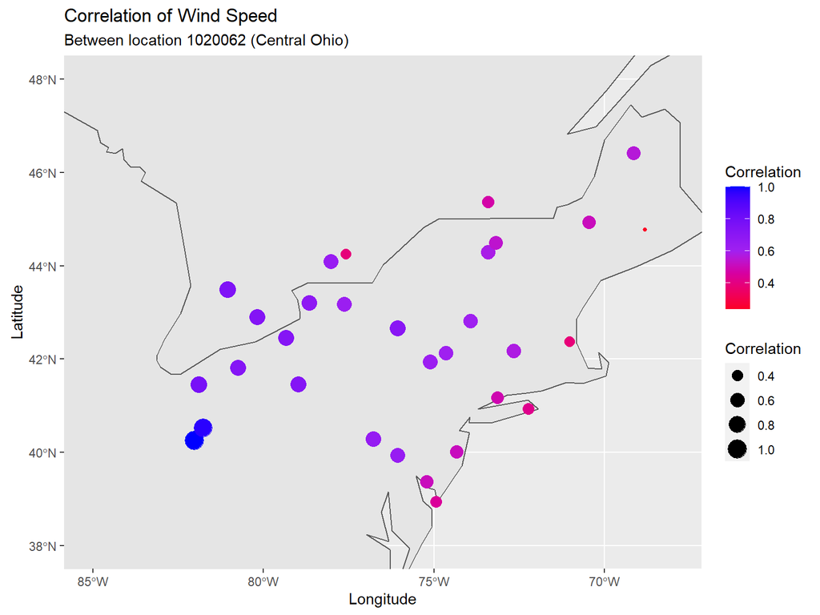

# Model

$$A\times(\cos(\frac{\pi*days}{182.5})+
A\times(\cos(\frac{\pi*days}{91.25})+
A\times(\cos(\frac{\pi*days}{45.625})+
A\times(\sin(\frac{\pi*days}{182.5})+
A\times(\sin(\frac{\pi*days}{91.25})+
A\times(\cos(\frac{\pi*days}{45.625})+
C$$

- This generic function was fitted with hundreds of combinations of parameters
- The performance was evaluated by measuring the error between model predictions and observations
- Selection Criteria
  - Min RMSE
- Repeated for all 31 locations

# Model Error

- The error was calculated for each observation and predicted value
  - Critical to appropriately model the error for the simulation

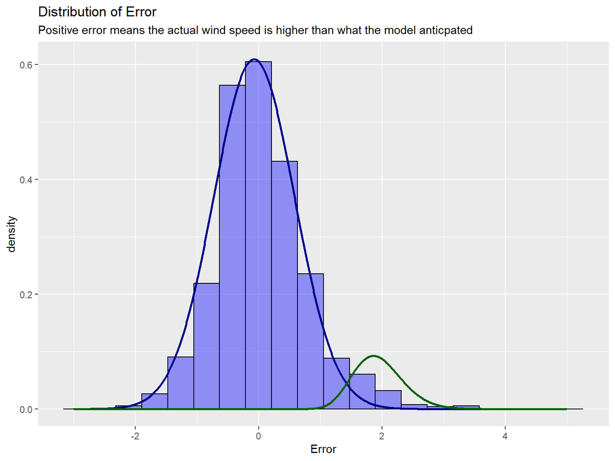

Viewing the distribution of errors for location 1079715 (Lake Erie)

$$\hat f(x)= f(x)+\epsilon$$

# Model Visual: Observered Wind Speed

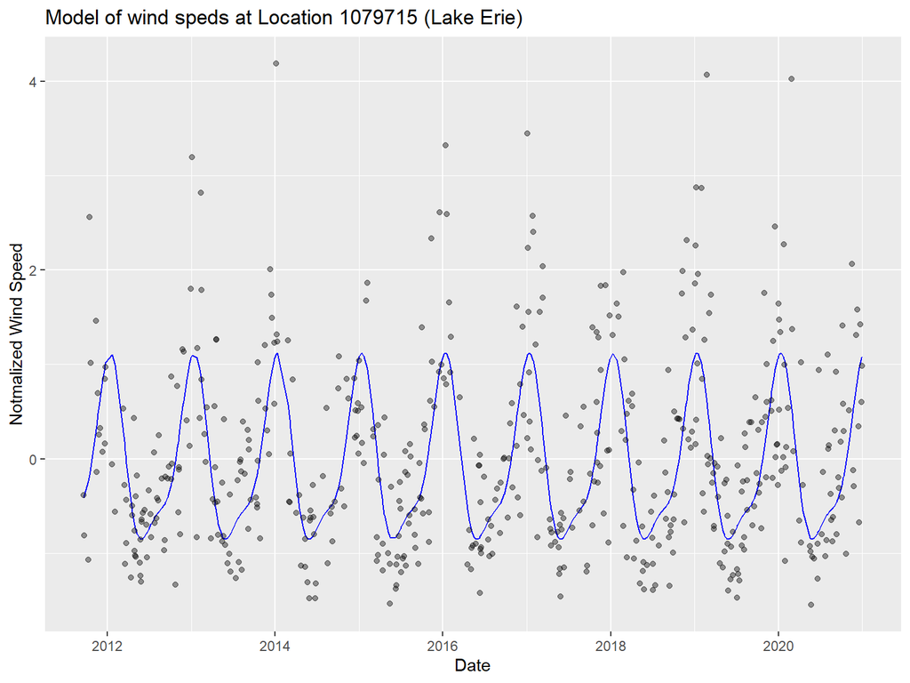

- Model captures the sinusoidal change in wind speed each year
  - Winters have higher wind speeds than the summer
- Issues
  - Positive errors:
    - Model strudels to predict the few very high average wind speeds in winter
  - Location’s with low wind speed:
    - More error - high and low wind speed
    - Less normal error

# Model Visual: Simualted Wind Speeds

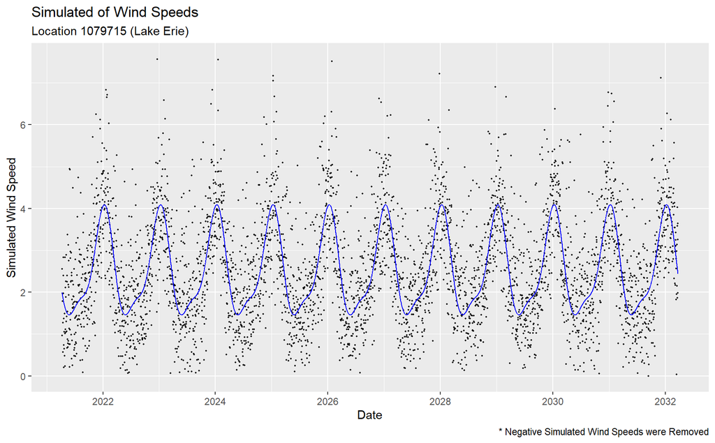

# Next steps

- Project {.bold}
  - Simulate all 31 locations wind speed with fitted models
  - Identify Insights
    - Examine the correlation between the locations simulated data
      - Highlight locations with the least correlation
    - Cluster analysis to discover more trends in the simulated data
- Post Project {.bold}
  - Model and simulate solar radiation for these locations
  - Add additional locations
  - Optimize placement of wind/solar farms